# Homework 6

Gavin Hyde

3/7/2022

Loading the data

```r
HAPPY = readRDS("data/HAPPY.rds")
library(ggplot2)
library(dplyr)
```

Part I

Data cleaning: the values “IAP”, “DK” and “NA” all encode missing values. Replace all of these instances by the value NA.

```r
HAPPY <- replace(HAPPY, HAPPY == "IAP", NA)
HAPPY <- replace(HAPPY, HAPPY == "DK", NA)
HAPPY <- replace(HAPPY, HAPPY == "NA", NA)
```

Check the type of the variable and cast into the right type (factor variable for categorical variables). For age, change “89 OR OLDER” to 89 and assume the variable should be numeric.

```r
HAPPY <- HAPPY %>% mutate(
  age = replace(AGE, AGE == "89 AND OLDER", 89),
  age = as.numeric(age)
) %>% select(-AGE)
```

Bringing levels of factors to a sensible order

```r
HAPPY <- HAPPY %>% mutate(
  degree = factor(tolower(DEGREE)),
  degree = factor(degree, levels=c("lt high school", "high school", "junior college", "bachelor", "graduate school"))
) %>% select(-DEGREE)
```

Part II

Personal Exploration- Gavin Hyde

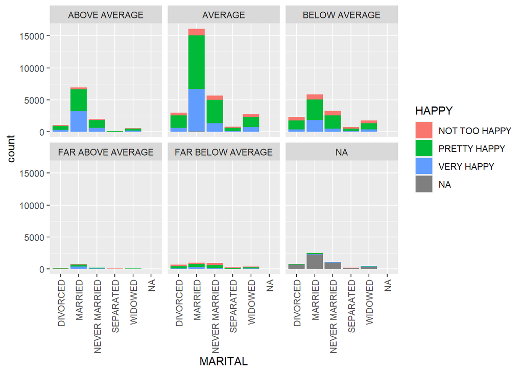

```r
HAPPY %>% ggplot(aes(x=MARITAL,fill=HAPPY)) +
  geom_bar() +
  facet_wrap(~FINRELA) +
  theme(axis.text.x = element_text(angle = 90, vjust = 0.5, hjust=1))
```

I looked into what connection financial and marital status had on how happy individuals are. It seems that most very happy people are married with average income. This is somewhat misleading however, since there are most people who are in the average income bracket. It seems that the greatest proportion of very happy people is in the above average, and married category. It also appears that there are most people married, as compared to any other marital status. Also, being above average, or average in income seems to make people less likely to be not too happy in general. I think this shows that financial security greatly increases the happiness of an individual. Both factors seem to greatly affect the happiness of a person.

Part III 1. Gavin Hyde My usual partner said that he had already completed the assignment on his own, I didn’t know who else to ask to be my partner, so I just did the same. I still pushed to the repository. 2. https://github.com/hyde-gavin/homework6.git